# My Solution steps

1. Copy the Dataframe to newdataframe
2. drop the unwanted column, Keep only Genre and movie Release Year
3. Add New column and fill the values in colum as 1, basically this is movie release count
4. group by dataframe on Movie Release Year and get the sum of all columns
5. Now the new Data farme has unique Year, total movie release in that year by Genre

```python
dfmlist5=dfmlist4.copy()
dfmlist5=dfmlist5.drop(['movie id','movie title','release date','unknown','Genre Count'],axis=1)
dfmlist5['Yearly Movie Release']=1
dfmlist5=dfmlist5.groupby(['R Year']).sum()
dfmlist5
```

| R Year | Action | Adventure | Animation | Childrens | Comedy | Crime | Documentary | Drama | Fantasy | Film-Noir | Horror | Musical | Mystery | Romance | Sci-Fi | Thriller | War | Western | Yearly Movie Release |
| --- | --- | --- | --- | --- | --- | --- | --- | --- | --- | --- | --- | --- | --- | --- | --- | --- | --- | --- | --- |
| 1922 | 0 | 0 | 0 | 0 | 0 | 0 | 0 | 0 | 0 | 0 | 1 | 0 | 0 | 0 | 0 | 0 | 0 | 0 | 1 |
| 1926 | 0 | 0 | 0 | 0 | 0 | 0 | 0 | 1 | 0 | 0 | 0 | 0 | 0 | 0 | 0 | 0 | 0 | 0 | 1 |
| 1930 | 0 | 0 | 0 | 0 | 0 | 0 | 0 | 1 | 0 | 0 | 0 | 0 | 0 | 0 | 0 | 0 | 0 | 0 | 1 |
| 1931 | 0 | 0 | 0 | 0 | 0 | 1 | 0 | 0 | 0 | 1 | 0 | 0 | 0 | 0 | 0 | 1 | 0 | 0 | 1 |
| 1932 | 0 | 0 | 0 | 0 | 0 | 0 | 0 | 0 | 0 | 0 | 0 | 0 | 0 | 1 | 0 | 0 | 1 | 0 | 1 |
| ... | ... | ... | ... | ... | ... | ... | ... | ... | ... | ... | ... | ... | ... | ... | ... | ... | ... | ... | ... |
| 1994 | 30 | 13 | 4 | 15 | 82 | 8 | 9 | 97 | 3 | 0 | 8 | 2 | 2 | 35 | 7 | 25 | 7 | 6 | 214 |
| 1995 | 40 | 22 | 6 | 21 | 63 | 11 | 5 | 89 | 3 | 1 | 14 | 3 | 5 | 37 | 15 | 39 | 5 | 2 | 219 |
| 1996 | 44 | 24 | 9 | 21 | 108 | 21 | 18 | 170 | 6 | 1 | 11 | 9 | 6 | 38 | 15 | 47 | 9 | 2 | 355 |
| 1997 | 46 | 20 | 3 | 22 | 87 | 30 | 6 | 113 | 4 | 2 | 8 | 5 | 18 | 51 | 13 | 54 | 14 | 0 | 286 |
| 1998 | 12 | 3 | 0 | 1 | 13 | 7 | 3 | 33 | 1 | 2 | 4 | 1 | 3 | 11 | 5 | 18 | 0 | 0 | 65 |

71 rows × 19 columns

1. Get the % release in each genre category by diving total movie release in the year

```python
dfmlist6=dfmlist5.div(dfmlist5['Yearly Movie Release'], axis= 0) * 100
dfmlist6=dfmlist6.drop(['Yearly Movie Release'],axis=1)
dfmlist6.style.set_precision(0)
dfmlist6
```

| R Year | Action | Adventure | Animation | Childrens | Comedy | Crime | Documentary | Drama | Fantasy | Film-Noir | Horror | Musical | Mystery | Romance | Sci-Fi | Thriller | War | Western |
| --- | --- | --- | --- | --- | --- | --- | --- | --- | --- | --- | --- | --- | --- | --- | --- | --- | --- | --- |
| 1922 | 0 | 0 | 0 | 0 | 0 | 0 | 0 | 0 | 0 | 0e+00 | 100 | 0e+00 | 0e+00 | 0 | 0 | 0 | 0 | 0e+00 |
| 1926 | 0 | 0 | 0 | 0 | 0 | 0 | 0 | 100 | 0 | 0e+00 | 0 | 0e+00 | 0e+00 | 0 | 0 | 0 | 0 | 0e+00 |
| 1930 | 0 | 0 | 0 | 0 | 0 | 0 | 0 | 100 | 0 | 0e+00 | 0 | 0e+00 | 0e+00 | 0 | 0 | 0 | 0 | 0e+00 |
| 1931 | 0 | 0 | 0 | 0 | 0 | 100 | 0 | 0 | 0 | 1e+02 | 0 | 0e+00 | 0e+00 | 0 | 0 | 100 | 0 | 0e+00 |
| 1932 | 0 | 0 | 0 | 0 | 0 | 0 | 0 | 0 | 0 | 0e+00 | 0 | 0e+00 | 0e+00 | 100 | 0 | 0 | 100 | 0e+00 |
| ... | ... | ... | ... | ... | ... | ... | ... | ... | ... | ... | ... | ... | ... | ... | ... | ... | ... | ... |
| 1994 | 14 | 6 | 2 | 7 | 38 | 4 | 4 | 45 | 1 | 0e+00 | 4 | 9e-01 | 9e-01 | 16 | 3 | 12 | 3 | 3e+00 |
| 1995 | 18 | 10 | 3 | 10 | 29 | 5 | 2 | 41 | 1 | 5e-01 | 6 | 1e+00 | 2e+00 | 17 | 7 | 18 | 2 | 9e-01 |
| 1996 | 12 | 7 | 3 | 6 | 30 | 6 | 5 | 48 | 2 | 3e-01 | 3 | 3e+00 | 2e+00 | 11 | 4 | 13 | 3 | 6e-01 |
| 1997 | 16 | 7 | 1 | 8 | 30 | 10 | 2 | 40 | 1 | 7e-01 | 3 | 2e+00 | 6e+00 | 18 | 5 | 19 | 5 | 0e+00 |
| 1998 | 18 | 5 | 0 | 2 | 20 | 11 | 5 | 51 | 2 | 3e+00 | 6 | 2e+00 | 5e+00 | 17 | 8 | 28 | 0 | 0e+00 |

71 rows × 18 columns

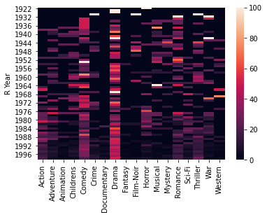

```python
sns.heatmap(dfmlist6, annot=False)
```

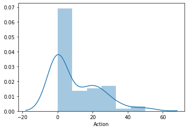

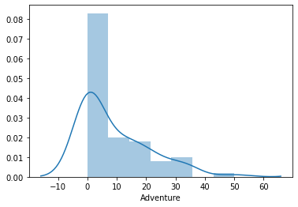

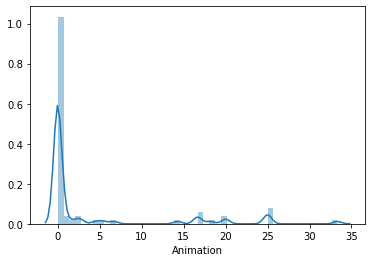

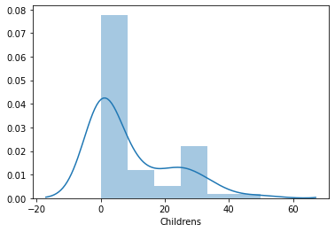

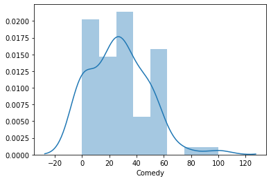

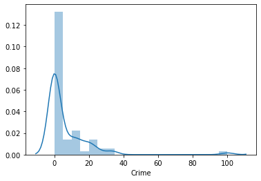

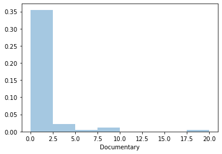

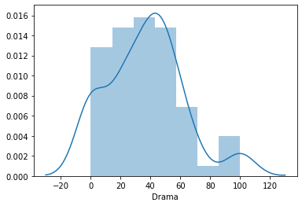

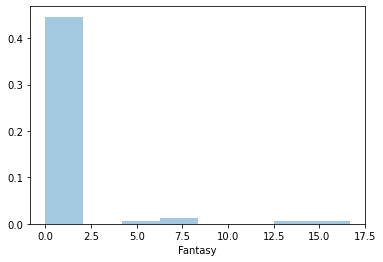

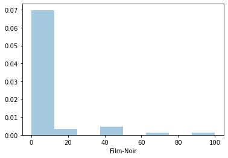

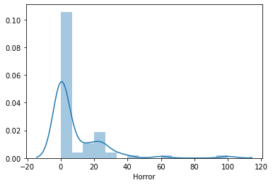

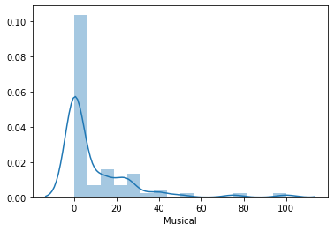

[6 more figures not shown]

```python
cname = dfmlist6.columns

for n, cname in enumerate(dfmlist6.columns):
    ax=sns.distplot(dfmlist6[cname])
    #ax.set_xticklabels(ax.get_xticklabels(), rotation=0, ha="right")
    plt.show()
```

Result :

1. Dramam & Comedy Movies are always one of the Poular category
2. Animation, Western not a poluplar Genre

### 9. Find the top 25 movies according to average ratings such that each movie has number of ratings more than 100 - 10 marks

Hints :

1. Find the count of ratings and average ratings for every movie.
2. Slice the movies which have ratings more than 100.
3. Sort values according to average rating such that movie which highest rating is on top.
4. Select top 25 movies.
5. You will have to use the .merge() function to get the movie titles.

Note: This question will need you to research about groupby and apply your findings. You can find more on groupby on https://realpython.com/pandas-groupby/.

# Steps i follow

1. copy the Movie rating dataset to new Dataframe
2. Add another colum to get Movie Average Rating
3. Use Groupby function on movie id to get the rating sum and feedback count
4. Make average Rating by sum of Rating / Rating count
5. Drop Unwanted columns and copy to new dataframe

```python
dfmrating1=dfmrating.copy()

dfmrating1['M Rating Count']=1
dfmrating2=dfmrating1.groupby(['movie id']).sum()
dfmrating2['Avg Rating'] = dfmrating2['rating'].div(dfmrating2['M Rating Count'], axis= 0)
dfmrating10=dfmrating2.copy()                                  # For final Merger of the Datbase
dfmrating2=dfmrating2.drop(['user id','timestamp'],axis=1)
dfmrating2.head()
```

| movie id | rating | M Rating Count | Avg Rating |
| --- | --- | --- | --- |
| 1 | 1753 | 452 | 4 |
| 2 | 420 | 131 | 3 |
| 3 | 273 | 90 | 3 |
| 4 | 742 | 209 | 4 |
| 5 | 284 | 86 | 3 |

# Steps i Follow

```python
dfmrating3 = dfmrating2.copy()
dfmrating3=dfmrating3[dfmrating3.rating >100]
dfmrating3.head()
```

| movie id | rating | M Rating Count | Avg Rating |
| --- | --- | --- | --- |
| 1 | 1753 | 452 | 4 |
| 2 | 420 | 131 | 3 |
| 3 | 273 | 90 | 3 |
| 4 | 742 | 209 | 4 |
| 5 | 284 | 86 | 3 |

# Steps i Follow

1. Extract Movie ID & Movie Title from Movile list Dataframe to new Datfarm 10
2. Set the moveie id as Index (not mandatory)
3. Merge the two dataframe to get Movie title updated in extracted Movie Rating List
4. Sort the movies in Descending Averge Rating Order
5. Extract Top 25 Movies from to new Dataframe
6. check the top 25 moview by issues dftop25.shape command (should include only 25 record)

```python
dfmlist10=dfmlist[['movie id','movie title']]
dfmlist10.set_index('movie id')
dfmrating4 = pd.merge(dfmlist10,dfmrating3, how='right', on='movie id')
dfmrating4 = dfmrating4.sort_values([('Avg Rating')], ascending=False)
dftop25=dfmrating4.head(25)
dftop25.head(25)
```

|  | movie id | movie title | rating | M Rating Count | Avg Rating |
| --- | --- | --- | --- | --- | --- |
| 347 | 408 | Close Shave, A | 503 | 112 | 4 |
| 284 | 318 | Schindler's List | 1331 | 298 | 4 |
| 146 | 169 | Wrong Trousers, The | 527 | 118 | 4 |
| 405 | 483 | Casablanca | 1083 | 243 | 4 |
| 97 | 114 | Wallace & Gromit: The Best of Aardman Animation | 298 | 67 | 4 |
| 56 | 64 | Shawshank Redemption, The | 1258 | 283 | 4 |
| 492 | 603 | Rear Window | 917 | 209 | 4 |
| 10 | 12 | Usual Suspects, The | 1171 | 267 | 4 |
| 42 | 50 | Star Wars | 2541 | 583 | 4 |
| 155 | 178 | 12 Angry Men | 543 | 125 | 4 |
| 435 | 513 | Third Man, The | 312 | 72 | 4 |
| 114 | 134 | Citizen Kane | 850 | 198 | 4 |
| 703 | 963 | Some Folks Call It a Sling Blade | 176 | 41 | 4 |
| 362 | 427 | To Kill a Mockingbird | 940 | 219 | 4 |
| 314 | 357 | One Flew Over the Cuckoo's Nest | 1133 | 264 | 4 |
| 86 | 98 | Silence of the Lambs, The | 1673 | 390 | 4 |
| 402 | 480 | North by Northwest | 767 | 179 | 4 |
| 108 | 127 | Godfather, The | 1769 | 413 | 4 |
| 255 | 285 | Secrets & Lies | 691 | 162 | 4 |
| 243 | 272 | Good Will Hunting | 844 | 198 | 4 |
| 227 | 251 | Shall We Dance? | 196 | 46 | 4 |
| 538 | 657 | Manchurian Candidate, The | 558 | 131 | 4 |
| 396 | 474 | Dr. Strangelove or: How I Learned to Stop Worr... | 825 | 194 | 4 |
| 151 | 174 | Raiders of the Lost Ark | 1786 | 420 | 4 |
| 401 | 479 | Vertigo | 761 | 179 | 4 |